# Growth Trials

Lilith Diener

2025-08-12

```r
options(repos = c(CRAN = "https://cloud.r-project.org"))
```

```r
library(gt)
library(tidyr)
library(dplyr)
library(readxl)
library(stringr)
library(dae)
library(ggplot2)
library(lme4)
library(lmerTest)
library(lubridate)
library(emmeans)
library(tidyverse)
library(styler)
library(ggpmisc)
library(car)
library(nlme)
library(tibble)
library(htmltools)
```

Reading in the data and setting the control treatment as baseline level

```r
# Read in data
final_data <- read_excel("C:/Users/Win10/Desktop/UCT/Honours Project Gracilaria/Data/Statistical_Analyses_R/Raw_data_complete.xlsx")


# Set the Control treatment as the reference/baseline level
final_data$Treatment <- as.factor(final_data$Treatment)
final_data$Treatment <- relevel(final_data$Treatment, ref = "Control")
```

## *Gracilaria gracilis*

### Length

Filtering the data and calculating averages

```r
# Filter data by species and length
gg_length <- final_data %>%
  filter(Measurement_Type == "Length", Species == "Gracilaria gracilis" )

# Calculate mean, SD and SE
gg_avg_length <- gg_length %>%
  group_by(Treatment, Tank_No,Week) %>%
  summarise(Average = mean(Value,na.rm = TRUE), SD = sd(Value), N = n(),
SE = SD / sqrt(N), Date = max(Date),.groups = "drop") %>%
  ungroup()

# Average treatment length per week
gg_avg_length_per_week_by_treatment <- gg_avg_length  %>%
  group_by( Week,Treatment) %>%
  summarise(
    Average = mean(Average,na.rm = TRUE), N = n(),
    SD = mean(SD,na.rm = TRUE), SE = mean(SE,na.rm = TRUE),
    Date = max(Date), .groups = "drop")
```

Testing ANOVA assumptions, creating models and running post hoc test

```r
# Shapiro-Wilk normality test to test normality of gg avg length per treatment per week
shapiro.test(gg_avg_length_per_week_by_treatment$Average) # normality assumption met
```

```
##
##  Shapiro-Wilk normality test
##
## data:  gg_avg_length_per_week_by_treatment$Average
## W = 0.88059, p-value = 0.08919
```

```r
# Levene's Test to check for homogeneity of treatments in gg avg length per treatment per week
leveneTest(gg_avg_length_per_week_by_treatment$Average,
gg_avg_length_per_week_by_treatment$Treatment, center = mean ) # assumption of equal variances met
```

```
## Levene's Test for Homogeneity of Variance (center = mean)
##       Df F value Pr(>F)
## group  2  1.0912 0.3764
##        9
```

```r
# Model of average length per treatment per week
mGAL <-  aov(Average ~ Treatment + Week, data = gg_avg_length_per_week_by_treatment)
summary(mGAL)
```

```
##             Df Sum Sq Mean Sq F value   Pr(>F)
## Treatment    2 134.50   67.25  142.50 5.56e-07 ***
## Week         1   4.77    4.77   10.11    0.013 *
## Residuals    8   3.78    0.47
## ---
## Signif. codes:  0 '***' 0.001 '**' 0.01 '*' 0.05 '.' 0.1 ' ' 1
```

```r
aov(mGAL)
```

```
## Call:
##    aov(formula = mGAL)
##
## Terms:
##                 Treatment      Week Residuals
## Sum of Squares  134.49879   4.77215   3.77537
## Deg. of Freedom         2         1         8
##
## Residual standard error: 0.6869653
## Estimated effects may be unbalanced
```

```r
anova(mGAL)
```

```
## Analysis of Variance Table
##
## Response: Average
##           Df  Sum Sq Mean Sq F value    Pr(>F)
## Treatment  2 134.499  67.249 142.501 5.557e-07 ***
## Week       1   4.772   4.772  10.112     0.013 *
## Residuals  8   3.775   0.472
## ---
## Signif. codes:  0 '***' 0.001 '**' 0.01 '*' 0.05 '.' 0.1 ' ' 1
```

```r
# Post hoc test
emmeans_mGAL <- emmeans(mGAL, pairwise ~ Treatment)
emmeans_mGAL$emmeans
```

```
##  Treatment emmean    SE df lower.CL upper.CL
##  Control    15.85 0.343  8    15.06    16.64
##  10         12.90 0.343  8    12.11    13.69
##  5           7.75 0.343  8     6.96     8.54
##
## Confidence level used: 0.95
```

```r
emmeans_mGAL$contrasts
```

```
##  contrast     estimate    SE df t.ratio p.value
##  Control - 10     2.95 0.486  8   6.070  0.0008
##  Control - 5      8.10 0.486  8  16.678  <.0001
##  10 - 5           5.15 0.486  8  10.607  <.0001
##
## P value adjustment: tukey method for comparing a family of 3 estimates
```

Figures

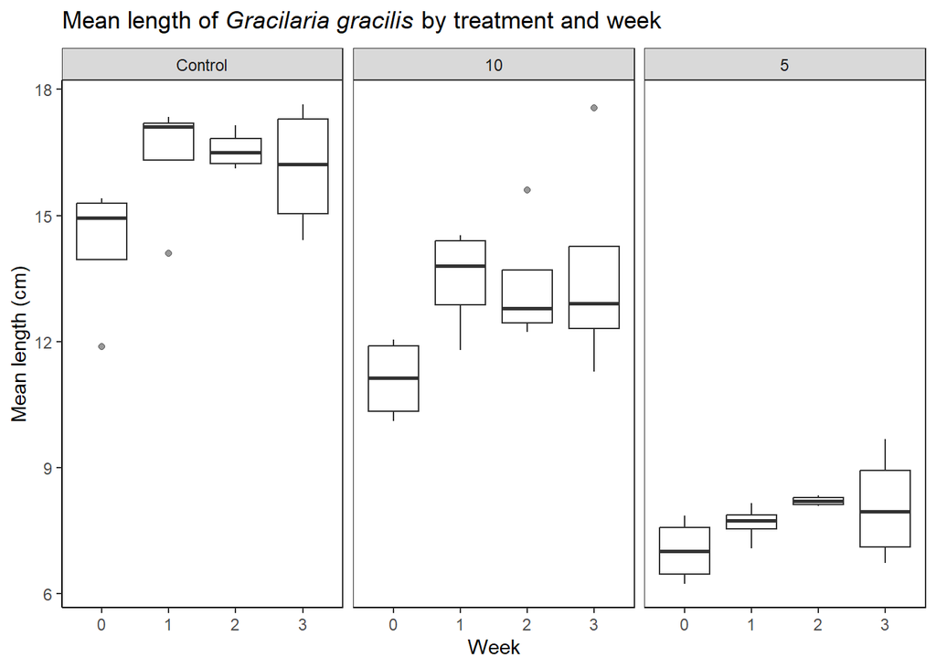

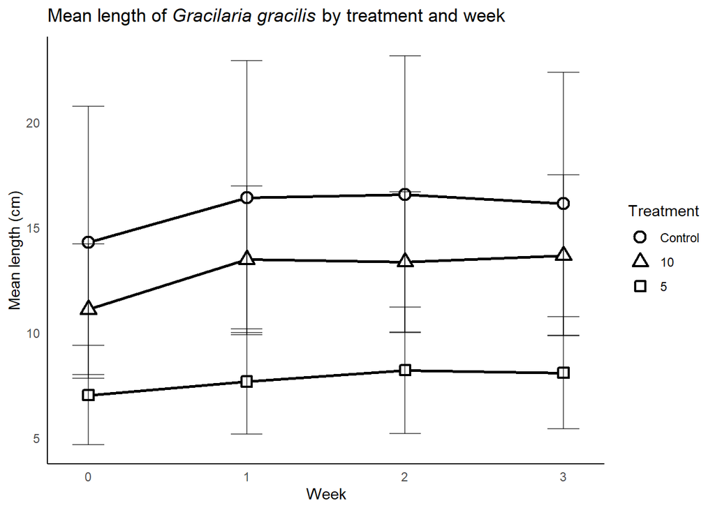

Specific Growth Rate (SGR) for Length

```r
#  Calculate specific growth rate (SGR) of length of both species of seaweed
gg_avg_length$Date <- as.Date(gg_avg_length$Date) # proper format

gg_rgr_length <- gg_avg_length %>%
arrange(Tank_No) %>%
group_by(Tank_No,Treatment) %>%
  mutate(Delta_Time = as.numeric((Date) - lag(Date)),
  RGR_Length = (log(Average) - lag(log(Average))) / Delta_Time,
  Tot_RGR = (Average[Week == 3]-Average[Week == 0])/as.numeric(max(Date)-min(Date)),
  RGR_Per =  ((log(Average) - lag(log(Average))) / Delta_Time)*100)

 rgr_weekly_sd <- gg_rgr_length %>%
  group_by(Week,Treatment) %>%
  mutate(
    SD_RGR_Per = sd(RGR_Per, na.rm = TRUE),
    N = sum(!is.na(RGR_Per)), SE_RGR_Per = SD_RGR_Per / sqrt(N)) %>%
   ungroup()

gg_avg_rgr_length <- rgr_weekly_sd %>%
  group_by(Treatment, Week) %>%
  summarise(
  RGR_Length = mean(RGR_Length,na.rm = TRUE), N = n(),
  Tot_RGR = mean(Tot_RGR, na.rm = TRUE),
  RGR_Per = mean(RGR_Per, na.rm = TRUE),
  RGR_Per_SD = mean(SD_RGR_Per, na.rm = TRUE),
  RGR_Per_SE = mean(SE_RGR_Per),
  Date = max(Date), .groups = "drop") %>%
ungroup()
```

SGR Figures

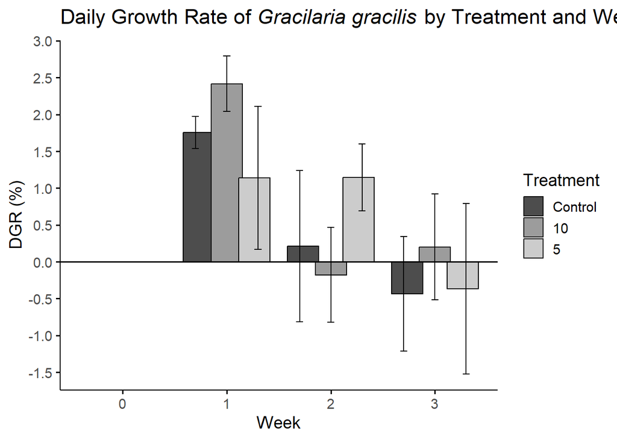

### Weight

Filtering the data and calculating averages

```r
gg_weight <- final_data %>%
  filter(Measurement_Type == "Weight", Species == "Gracilaria gracilis" )

# Calculate mean, SD and SE
gg_avg_weight <- gg_weight %>%
  group_by(Treatment,Tank_No,Week) %>%
  summarise(
  Average = mean(Value,na.rm = TRUE),N = n(), SD = sd(Value, na.rm = TRUE), SE =       SD / sqrt(N),Date = max(Date),.groups = "drop") %>%
  ungroup()

# Average treatment weight per week
 gg_avg_weight_per_week_by_treatment <- gg_avg_weight %>%
  group_by(Week,Treatment) %>%
  summarise(Average = mean(Average,na.rm = TRUE), N= n(), SD = mean(SD,na.rm = TRUE), SE = mean(SE,na.rm = TRUE), Date = max(Date), .groups = "drop") %>%
  ungroup()
```

Testing ANOVA Assumptions, creating models and running post hoc test

```r
# Shapiro-Wilk normality test to test normality of gg avg weight per treatment per week
shapiro.test(gg_avg_weight_per_week_by_treatment$Average) # assumption of normality met
```

```
##
##  Shapiro-Wilk normality test
##
## data:  gg_avg_weight_per_week_by_treatment$Average
## W = 0.88293, p-value = 0.09556
```

```r
# Levene's Test to check for homogeneity of treatments in gg avg weight per treatment per week
leveneTest(Average ~ Treatment, center = mean, data = gg_avg_weight_per_week_by_treatment) # assumption of equal variances met
```

```
## Levene's Test for Homogeneity of Variance (center = mean)
##       Df F value Pr(>F)
## group  2  0.5483 0.5961
##        9
```

```r
# Model of average weight per treatment per week
mGAW <-  lm(Average ~ Treatment + Week, data = gg_avg_weight_per_week_by_treatment)
summary(mGAW)
```

```
##
## Call:
## lm(formula = Average ~ Treatment + Week, data = gg_avg_weight_per_week_by_treatment)
##
## Residuals:
##     Min      1Q  Median      3Q     Max
## -13.870  -4.413   2.058   4.910  11.134
##
## Coefficients:
##             Estimate Std. Error t value Pr(>|t|)
## (Intercept) 148.0262     5.7350  25.811 5.45e-09 ***
## Treatment10   0.8944     6.4119   0.139    0.893
## Treatment5   -8.6456     6.4119  -1.348    0.214
## Week         32.3013     2.3413  13.796 7.36e-07 ***
## ---
## Signif. codes:  0 '***' 0.001 '**' 0.01 '*' 0.05 '.' 0.1 ' ' 1
##
## Residual standard error: 9.068 on 8 degrees of freedom
## Multiple R-squared:  0.9602, Adjusted R-squared:  0.9453
## F-statistic: 64.35 on 3 and 8 DF,  p-value: 6.072e-06
```

```r
anova(mGAW)
```

```
## Analysis of Variance Table
##
## Response: Average
##           Df  Sum Sq Mean Sq  F value    Pr(>F)
## Treatment  2   222.1   111.0   1.3504    0.3124
## Week       1 15650.6 15650.6 190.3393 7.357e-07 ***
## Residuals  8   657.8    82.2
## ---
## Signif. codes:  0 '***' 0.001 '**' 0.01 '*' 0.05 '.' 0.1 ' ' 1
```

```r
# Post hoc test
emmeans_mGAW <- emmeans(mGAW, pairwise ~ Treatment)
emmeans_mGAW$emmeans
```

```
##  Treatment emmean   SE df lower.CL upper.CL
##  Control      196 4.53  8      186      207
##  10           197 4.53  8      187      208
##  5            188 4.53  8      177      198
##
## Confidence level used: 0.95
```

```r
emmeans_mGAW$contrasts
```

```
##  contrast     estimate   SE df t.ratio p.value
##  Control - 10   -0.894 6.41  8  -0.139  0.9893
##  Control - 5     8.646 6.41  8   1.348  0.4101
##  10 - 5          9.540 6.41  8   1.488  0.3461
##
## P value adjustment: tukey method for comparing a family of 3 estimates
```

Figures of average weight

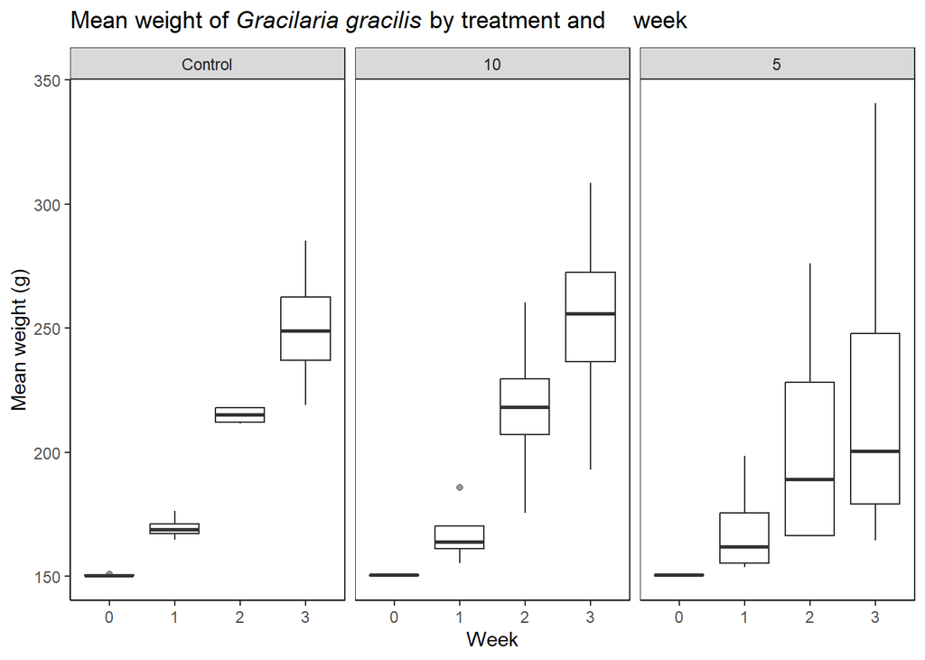

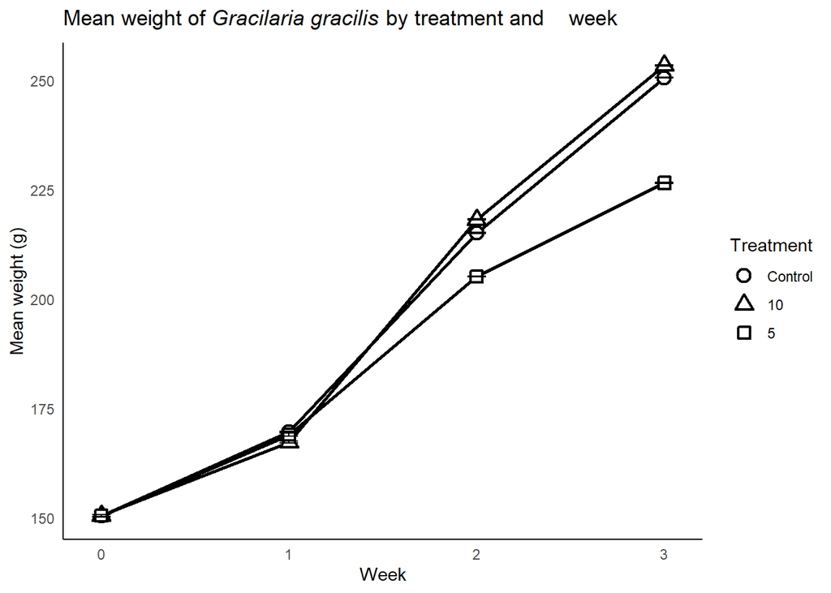

SGR

```r
# Calculating SGR of weight by treatment
gg_avg_weight$Date <- as.Date(gg_avg_weight$Date) # proper format

gg_rgr_weight <- gg_avg_weight %>%
arrange(Tank_No) %>%
group_by(Tank_No,Treatment) %>%
  mutate(Delta_Time = as.numeric((Date) - lag(Date)),
  RGR_Weight = (log(Average) - lag(log(Average))) / Delta_Time,
  Tot_RGR = (Average[Week == 3]-Average[Week == 0])/as.numeric(max(Date)-min(Date)),
  RGR_Per =  ((log(Average) - lag(log(Average))) / Delta_Time)*100)

rgr_weekly_sd <- gg_rgr_weight %>%
  group_by(Week,Treatment) %>%
  mutate(
    RGR_Per_SD = sd(RGR_Per, na.rm = TRUE),
     N = sum(!is.na(RGR_Per)), SE_RGR_Per = RGR_Per_SD / sqrt(N)) %>%
  ungroup()

gg_avg_rgr_weight <- rgr_weekly_sd %>%
  group_by(Treatment, Week) %>%
  summarise(
  RGR_Weight = mean(RGR_Weight,na.rm = TRUE), N = n(),
  Tot_RGR = mean(Tot_RGR, na.rm = TRUE),
   RGR_Per =mean(RGR_Per, na.rm = TRUE),
   RGR_Per_SD =mean(RGR_Per_SD, na.rm = TRUE),
   RGR_Per_SE = mean(SE_RGR_Per, na.rm = TRUE),
  Date = max(Date), .groups = "drop")
```

SGR Figures

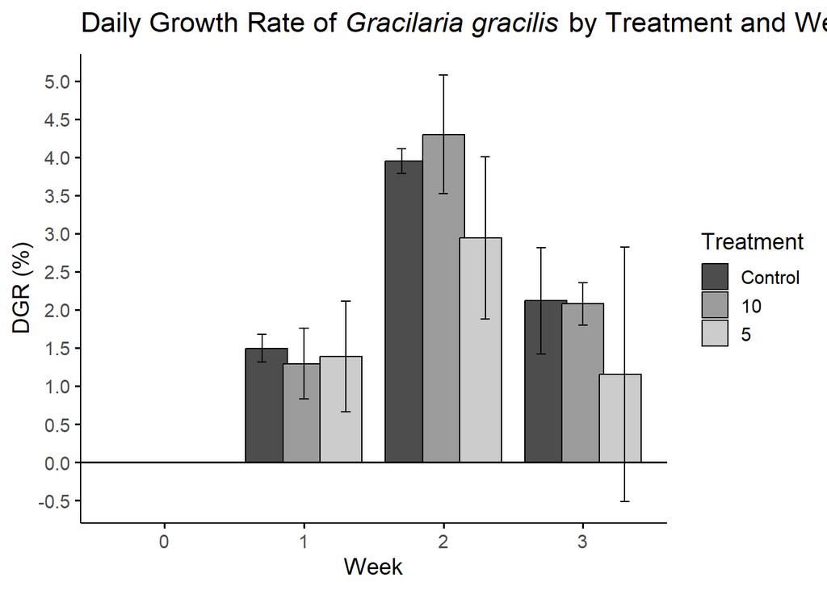

## *Gracilariopsis longissima*

### Length

Filtering the data and calculating averages

```r
gl_length <- final_data %>%
  filter(Measurement_Type == "Length", Species == "Gracilariopsis longissima" )

# Calculate mean SD and SE
gl_avg_length <- gl_length %>%
  group_by(Treatment, Tank_No,Week) %>%
  summarise(Average = mean(Value,na.rm = TRUE),N = n(), SD = sd(Value),
            SE = SD / sqrt(N),Date = max(Date),.groups = "drop") %>%
  ungroup()

# Average treatment length per week
gl_avg_length_per_week_by_treatment <- gl_avg_length  %>%
  group_by( Week,Treatment) %>%
  summarise(
    Average = mean(Average,na.rm = TRUE), N = n(),
    SD = mean(SD,na.rm = TRUE), SE = mean(SE,na.rm = TRUE),
    Date = max(Date), .groups = "drop")
```

Testing ANOVA Assumptions, modelling and post hoc test

```r
# Shapiro-Wilk normality test
shapiro.test(gl_avg_length_per_week_by_treatment$Average) # normality assumption not met
```

```
##
##  Shapiro-Wilk normality test
##
## data:  gl_avg_length_per_week_by_treatment$Average
## W = 0.8447, p-value = 0.0316
```

```r
# Levene's Test to check for homogeneity of treatments
leveneTest(Average ~ Treatment, center = mean, data = gl_avg_length_per_week_by_treatment) # equal variances assumption not met
```

```
## Levene's Test for Homogeneity of Variance (center = mean)
##       Df F value  Pr(>F)
## group  2  5.2489 0.03084 *
##        9
## ---
## Signif. codes:  0 '***' 0.001 '**' 0.01 '*' 0.05 '.' 0.1 ' ' 1
```

```r
# Use generalised least squares model instead of linear model
m_LAL <- gls(
  Average ~ Treatment + Week,
  weights = varIdent(form = ~1 | Treatment),
  data = gl_avg_length_per_week_by_treatment
)
summary(m_LAL)
```

```
## Generalized least squares fit by REML
##   Model: Average ~ Treatment + Week
##   Data: gl_avg_length_per_week_by_treatment
##        AIC      BIC    logLik
##   30.80313 31.35922 -8.401565
##
## Variance function:
##  Structure: Different standard deviations per stratum
##  Formula: ~1 | Treatment
##  Parameter estimates:
##    Control         10          5
## 1.00000000 0.01784444 0.03638508
##
## Coefficients:
##                  Value Std.Error    t-value p-value
## (Intercept)  29.669442 2.2556729  13.153255   0e+00
## Treatment10 -16.559210 2.2555111  -7.341666   1e-04
## Treatment5  -22.842126 2.2566444 -10.122165   0e+00
## Week          0.651234 0.0323121  20.154495   0e+00
##
##  Correlation:
##             (Intr) Trtm10 Trtmn5
## Treatment10 -1.000
## Treatment5  -0.999  0.999
## Week        -0.021  0.000  0.000
##
## Standardized residuals:
##        Min         Q1        Med         Q3        Max
## -1.3697327 -0.5707179  0.2450597  0.6495014  0.9658079
##
## Residual standard error: 4.510304
## Degrees of freedom: 12 total; 8 residual
```

```r
anova(m_LAL)
```

```
## Denom. DF: 8
##             numDF  F-value p-value
## (Intercept)     1 126984.2  <.0001
## Treatment       2   2394.2  <.0001
## Week            1    406.2  <.0001
```

```r
# Post hoc test
emmeans_gls <- emmeans(m_LAL, pairwise ~ Treatment)
emmeans_gls$emmeans
```

```
##  Treatment emmean     SE   df lower.CL upper.CL
##  Control     30.6 2.2600 3.00    23.47    37.83
##  10          14.1 0.0402 1.97    13.91    14.26
##  5            7.8 0.0821 2.63     7.52     8.09
##
## Degrees-of-freedom method: satterthwaite
## Confidence level used: 0.95
```

```r
emmeans_gls$contrasts
```

```
##  contrast     estimate     SE   df t.ratio p.value
##  Control - 10    16.56 2.2600 3.00   7.342  0.0107
##  Control - 5     22.84 2.2600 3.01  10.122  0.0042
##  10 - 5           6.28 0.0914 3.91  68.748  <.0001
##
## Degrees-of-freedom method: satterthwaite
## P value adjustment: tukey method for comparing a family of 3 estimates
```

Figures of average length

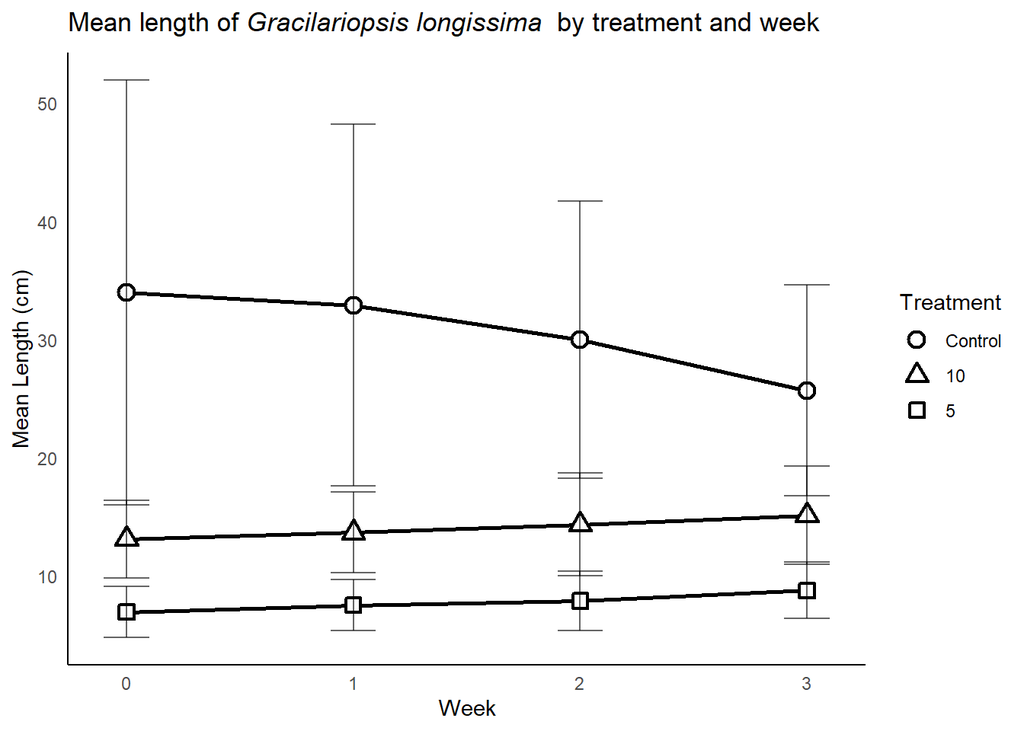

SGR (Length)

```r
#  Calculate specific growth rate (SGR) of length of Gracilariopsis longissima
gl_avg_length$Date <- as.Date(gl_avg_length$Date) # proper format

gl_rgr_length <- gl_avg_length %>%
arrange(Tank_No) %>%
group_by(Tank_No,Treatment) %>%
  mutate(Delta_Time = as.numeric((Date) - lag(Date)),
  RGR_Length = (log(Average) - lag(log(Average))) / Delta_Time,
  Tot_RGR = (Average[Week == 3]-Average[Week == 0])/as.numeric(max(Date)-min(Date)),
   RGR_Per = ((log(Average) - lag(log(Average))) / Delta_Time)*100)

rgr_weekly_sd <- gl_rgr_length %>%
  group_by(Week,Treatment) %>%
  mutate(
    RGR_Per_SD = sd(RGR_Per, na.rm = TRUE),
  N = sum(!is.na(RGR_Per)),
  SE_RGR_Per = RGR_Per_SD / sqrt(N)) %>%
  ungroup()


gl_avg_rgr_length <- rgr_weekly_sd %>%
  group_by(Treatment, Week) %>%
  summarise(
  RGR_Length = mean(RGR_Length,na.rm = TRUE), N = n(),
  Tot_RGR = mean(Tot_RGR, na.rm = TRUE),
    RGR_Per = mean(RGR_Per, na.rm = TRUE),
    RGR_Per_SD = mean(RGR_Per_SD, na.rm = TRUE),
  RGR_Per_SE = mean(SE_RGR_Per, na.rm = TRUE),
  Date = max(Date), .groups = "drop") %>%
ungroup()
```

SGR Figures

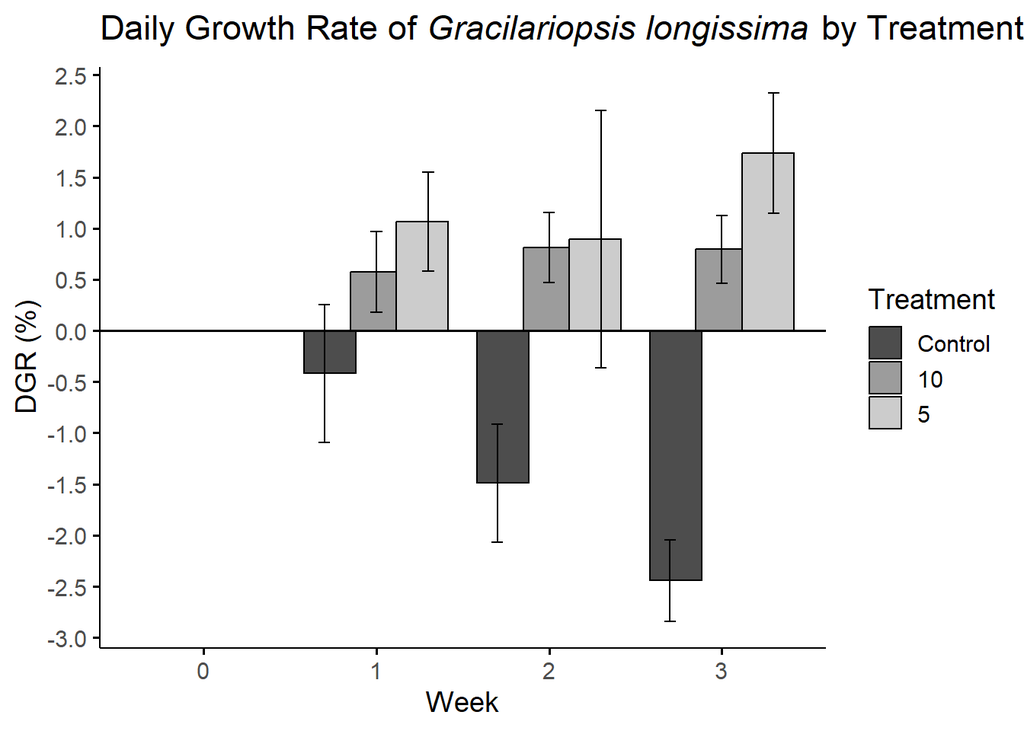

### Weight

```r
#  Specific growth rate (SGR) of weight of Gracilariopsis longissima
gl_weight <- final_data %>%
  filter(Measurement_Type == "Weight", Species == "Gracilariopsis longissima" )

# Calculate mean, SD and SE
gl_avg_weight <- gl_weight %>%
  group_by(Treatment,Tank_No,Week) %>%
  summarise(
  Average = mean(Value,na.rm = TRUE),N = n(), SD = sd(Value, na.rm = TRUE), SE = SD / sqrt(N),Date = max(Date),.groups = "drop") %>%
  ungroup()

# Average treatment weight per week
gl_avg_weight_per_week_by_treatment <- gl_avg_weight %>%
  group_by(Week,Treatment) %>%
  summarise(Average = mean(Average,na.rm = TRUE), N= n(), SD = mean(SD,na.rm = TRUE), SE = mean(SE,na.rm = TRUE), Date = max(Date), .groups = "drop") %>%
  ungroup()
```

Testing ANOVA assumptions and modelling

```r
# Shapiro-Wilk normality test
shapiro.test(gl_avg_weight_per_week_by_treatment$Average) # normality assumption met
```

```
##
##  Shapiro-Wilk normality test
##
## data:  gl_avg_weight_per_week_by_treatment$Average
## W = 0.91583, p-value = 0.2532
```

```r
# Levene's Test to check for homogeneity
leveneTest(Average ~ Treatment, center = mean, data = gl_avg_weight_per_week_by_treatment) # equal variances assumption met
```

```
## Levene's Test for Homogeneity of Variance (center = mean)
##       Df F value Pr(>F)
## group  2  0.1086 0.8982
##        9
```

```r
# Model average weight per treatment per week
mLAW <-  lm(Average ~ Treatment + Week, data = gl_avg_weight_per_week_by_treatment)

summary(mLAW)
```

```
##
## Call:
## lm(formula = Average ~ Treatment + Week, data = gl_avg_weight_per_week_by_treatment)
##
## Residuals:
##     Min      1Q  Median      3Q     Max
## -5.9260 -2.1542 -0.6333  2.5941  7.0187
##
## Coefficients:
##             Estimate Std. Error t value Pr(>|t|)
## (Intercept)  147.774      2.773  53.293 1.70e-11 ***
## Treatment10    5.795      3.100   1.869   0.0985 .
## Treatment5    -4.498      3.100  -1.451   0.1849
## Week          14.769      1.132  13.047 1.13e-06 ***
## ---
## Signif. codes:  0 '***' 0.001 '**' 0.01 '*' 0.05 '.' 0.1 ' ' 1
##
## Residual standard error: 4.384 on 8 degrees of freedom
## Multiple R-squared:  0.9577, Adjusted R-squared:  0.9419
## F-statistic: 60.44 on 3 and 8 DF,  p-value: 7.715e-06
```

```r
anova(mLAW)
```

```
## Analysis of Variance Table
##
## Response: Average
##           Df Sum Sq Mean Sq  F value    Pr(>F)
## Treatment  2  213.0   106.5   5.5406    0.0309 *
## Week       1 3272.0  3272.0 170.2258 1.131e-06 ***
## Residuals  8  153.8    19.2
## ---
## Signif. codes:  0 '***' 0.001 '**' 0.01 '*' 0.05 '.' 0.1 ' ' 1
```

```r
aov(mLAW)
```

```
## Call:
##    aov(formula = mLAW)
##
## Terms:
##                 Treatment     Week Residuals
## Sum of Squares    213.000 3272.047   153.774
## Deg. of Freedom         2        1         8
##
## Residual standard error: 4.384268
## Estimated effects may be unbalanced
```

```r
# Post hoc test
emmeans_mLAW <- emmeans(mLAW, pairwise ~ Treatment)
emmeans_mLAW$emmeans
```

```
##  Treatment emmean   SE df lower.CL upper.CL
##  Control      170 2.19  8      165      175
##  10           176 2.19  8      171      181
##  5            165 2.19  8      160      170
##
## Confidence level used: 0.95
```

```r
emmeans_mLAW$contrasts
```

```
##  contrast     estimate  SE df t.ratio p.value
##  Control - 10    -5.79 3.1  8  -1.869  0.2092
##  Control - 5      4.50 3.1  8   1.451  0.3623
##  10 - 5          10.29 3.1  8   3.320  0.0255
##
## P value adjustment: tukey method for comparing a family of 3 estimates
```

Figures average weight

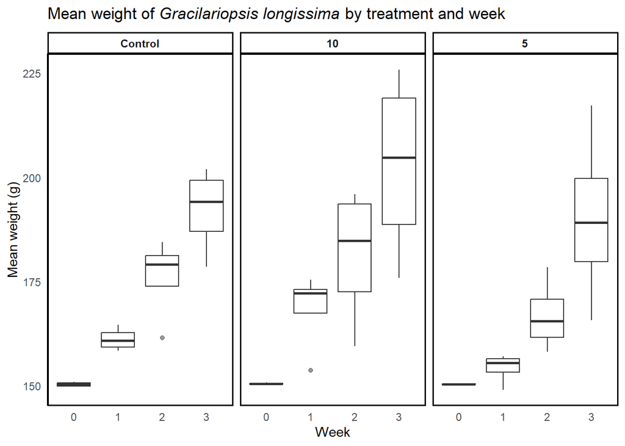

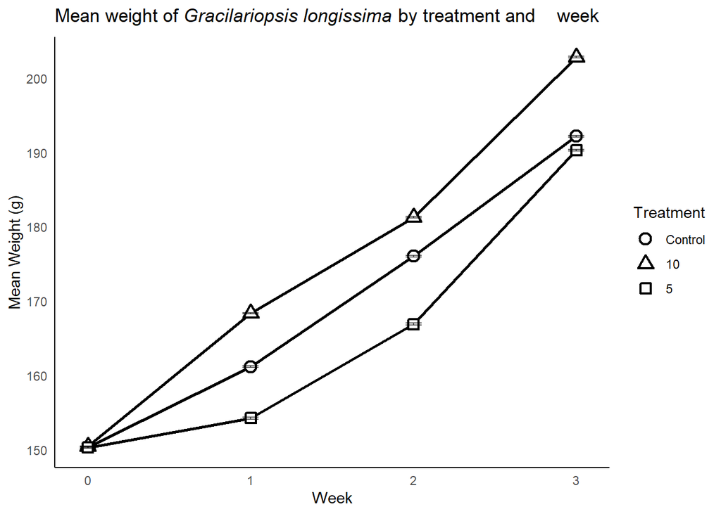

SGR

```r
gl_avg_weight$Date <- as.Date(gl_avg_weight$Date) # make sure date is formatted

gl_rgr_weight <- gl_avg_weight %>%
arrange(Tank_No) %>%
group_by(Tank_No,Treatment) %>%
  mutate(Delta_Time = as.numeric((Date) - lag(Date)),
  RGR_Weight = (log(Average) - lag(log(Average))) / Delta_Time,
  Tot_RGR = (Average[Week == 3]-Average[Week == 0])/as.numeric(max(Date)-min(Date)),
  RGR_Per = ((log(Average) - lag(log(Average))) / Delta_Time)*100)

rgr_weekly_sd <- gl_rgr_weight %>%
  group_by(Week,Treatment) %>%
  mutate(
    RGR_Per_SD = sd(RGR_Per, na.rm = TRUE),
  N = sum(!is.na(RGR_Per)),
  SE_RGR_Per = RGR_Per_SD / sqrt(N)) %>%
  ungroup()


gl_avg_rgr_weight <- rgr_weekly_sd %>%
  group_by(Treatment, Week) %>%
  summarise(
  RGR_Weight = mean(RGR_Weight,na.rm = TRUE), N = n(),
  Tot_RGR = mean(Tot_RGR, na.rm = TRUE),
  RGR_Per = mean(RGR_Per, na.rm = TRUE),
  RGR_Per_SD = mean(RGR_Per_SD, na.rm = TRUE),
  RGR_Per_SE = mean(SE_RGR_Per, na.rm = TRUE),
  Date = max(Date), .groups = "drop") %>%
ungroup()
```

SGR Figures

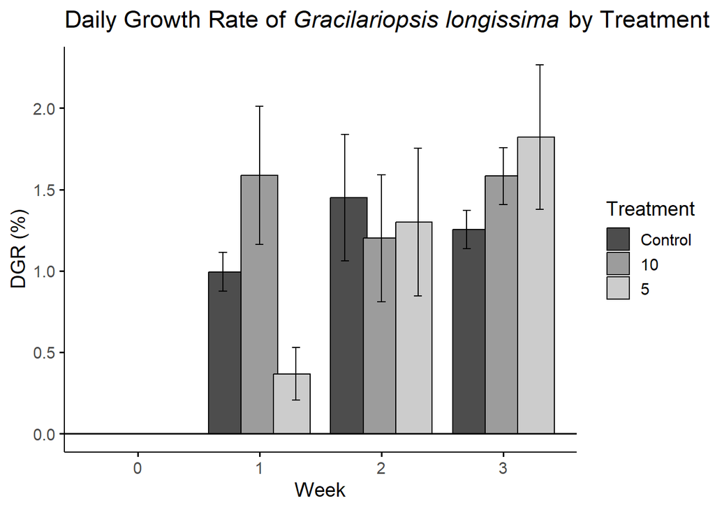

Relationship between total length and wet weight of three cuttings in *Gracilaria gracilis*

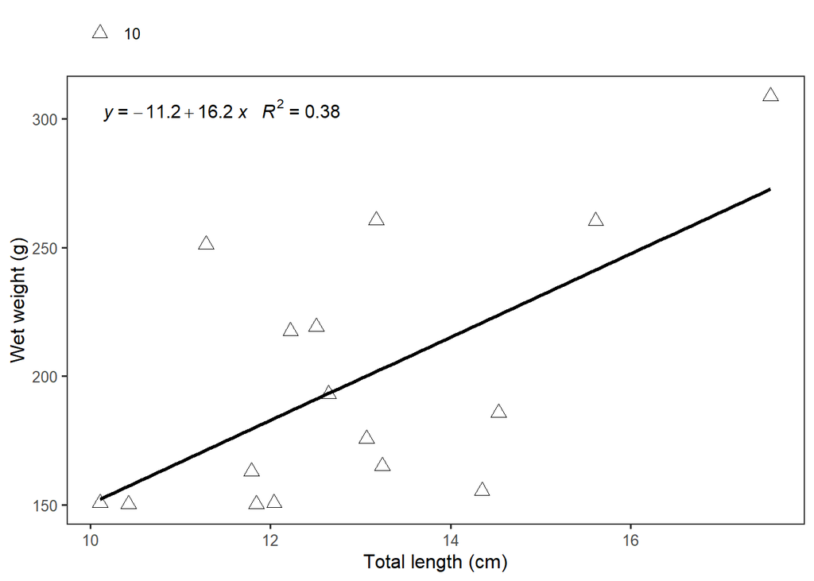

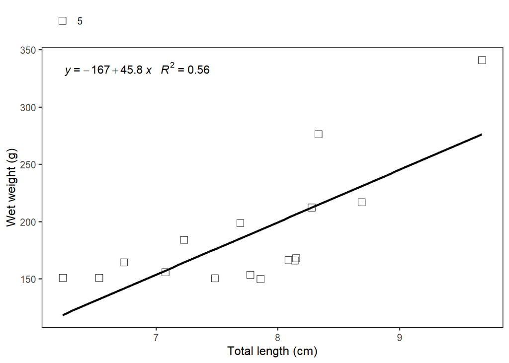

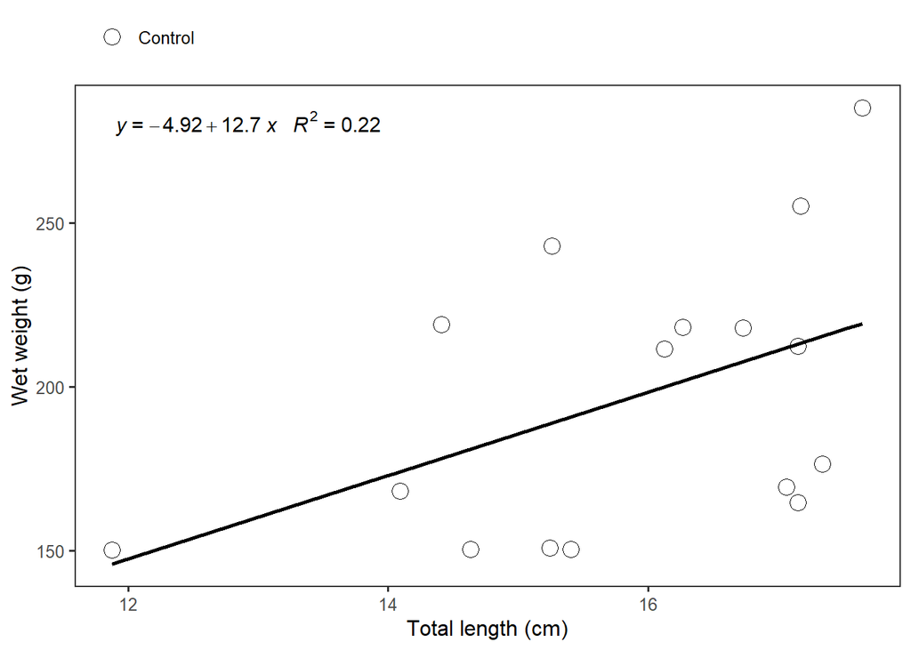

Relationship between total length and wet weight of three cuttings in *Gracilariopsis longissima*

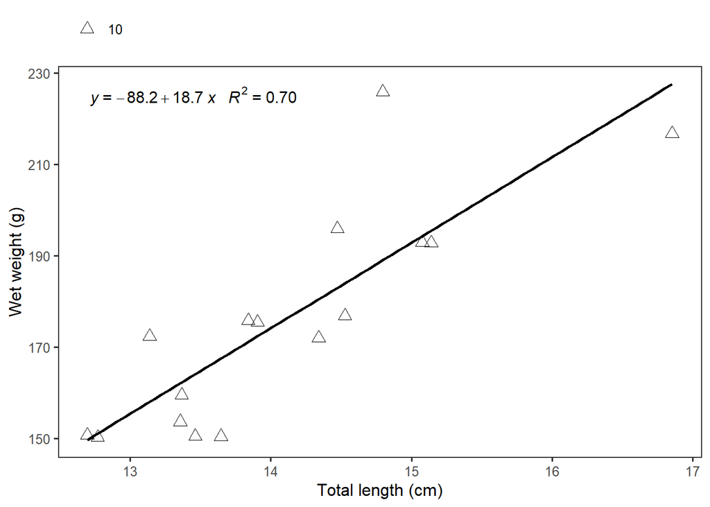

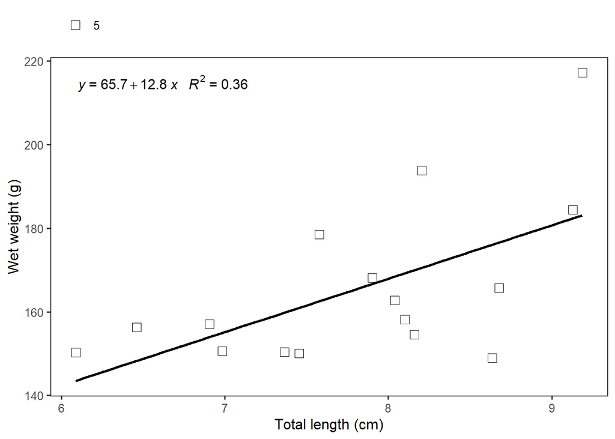

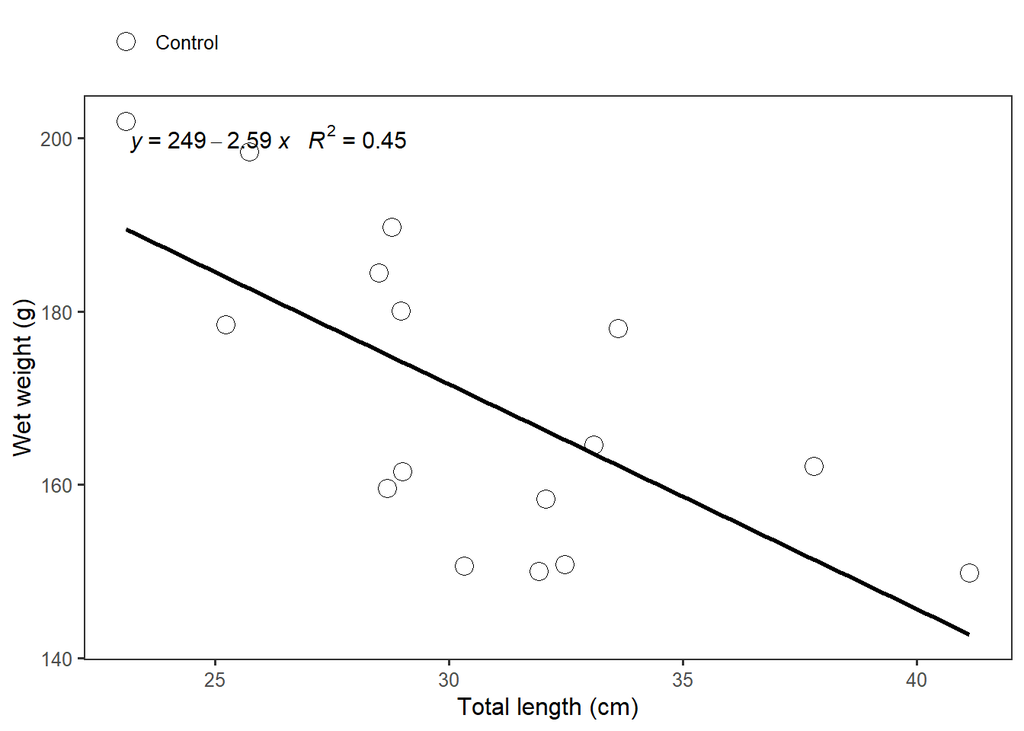

Tables: ANOVA, Average lengths and Specific growth rates

**Analysis of variance between total length and wet weight of three kinds of cuttings in *Gracilaria gracilis***

| Cutting length | Source | Sum of squares | df | Mean squares | F value | F0.05 |
| --- | --- | --- | --- | --- | --- | --- |
| Control | Regression | 8.02 | 1.00 | 8.02 | 3.95 | 4.60 |
|  | Residual | 28.46 | 14.00 | 2.03 | NA | 4.60 |
|  | Total | 36.48 | 15.00 | NA | NA | 4.60 |
| 5 | Regression | 6.27 | 1.00 | 6.27 | 17.59 | 4.60 |
|  | Residual | 4.99 | 14.00 | 0.36 | NA | 4.60 |
|  | Total | 11.25 | 15.00 | NA | NA | 4.60 |
| 10 | Regression | 20.60 | 1.00 | 20.60 | 8.55 | 4.60 |
|  | Residual | 33.74 | 14.00 | 2.41 | NA | 4.60 |
|  | Total | 54.33 | 15.00 | NA | NA | 4.60 |

**Analysis of variance between total length and wet weight of three kinds of cuttings in *Gracilariopsis longissima***

| Cutting length | Source | Sum of squares | df | Mean squares | F value | F0.05 |
| --- | --- | --- | --- | --- | --- | --- |
| Control | Regression | 140.41 | 1.00 | 140.41 | 11.54 | 4.60 |
|  | Residual | 170.38 | 14.00 | 12.17 | NA | 4.60 |
|  | Total | 310.80 | 15.00 | NA | NA | 4.60 |
| 5 | Regression | 4.36 | 1.00 | 4.36 | 7.82 | 4.60 |
|  | Residual | 7.81 | 14.00 | 0.56 | NA | 4.60 |
|  | Total | 12.17 | 15.00 | NA | NA | 4.60 |
| 10 | Regression | 11.83 | 1.00 | 11.83 | 32.42 | 4.60 |
|  | Residual | 5.11 | 14.00 | 0.37 | NA | 4.60 |
|  | Total | 16.94 | 15.00 | NA | NA | 4.60 |

Total length (cm) of cuttings cut from individuals of *Gracilaria gracilis*

**Total length (mean, cm)**

| Treatment | Mean length (cm) Week 0 ( 0 ) | Mean length (cm) Week 1 ( 8 ) | Mean length (cm) Week 2 ( 14 ) | Mean length (cm) Week 3 ( 21 ) |
| --- | --- | --- | --- | --- |
| Control | 14.29 | 16.41 | 16.57 | 16.12 |
| 10 | 11.10 | 13.48 | 13.35 | 13.67 |
| 5 | 7.03 | 7.67 | 8.21 | 8.08 |

**Specific growth rate**

| Treatment | RGR per Time Period (Days) 0-0 | RGR per Time Period (Days) 0-8 | RGR per Time Period (Days) 8-14 | RGR per Time Period (Days) 14-21 | Total RGR (Days) (0-21) |
| --- | --- | --- | --- | --- | --- |
| Control | 0.00000 | 0.01755 | 0.00213 | −0.00435 | 0.08732 |
| 10 | 0.00000 | 0.02416 | −0.00178 | 0.00202 | 0.12198 |
| 5 | 0.00000 | 0.01139 | 0.01144 | −0.00366 | 0.05030 |

Total length (cm) of cuttings cut from individuals of *Gracilariopsis longissima*

**Total length (mean, cm)**

| Treatment | Mean length (cm) Week 0 ( 0 ) | Mean length (cm) Week 1 ( 7 ) | Mean length (cm) Week 2 ( 13 ) | Mean length (cm) Week 3 ( 20 ) |
| --- | --- | --- | --- | --- |
| Control | 33.96 | 32.90 | 30.02 | 25.70 |
| 10 | 13.14 | 13.69 | 14.38 | 15.14 |
| 5 | 6.97 | 7.54 | 7.91 | 8.80 |

**Specific growth rate**

| Treatment | SGR per Time Period (Days) 0-0 | SGR per Time Period (Days) 0-7 | SGR per Time Period (Days) 7-13 | SGR per Time Period (Days) 13-20 | Total RGR (Days) (0-20) |
| --- | --- | --- | --- | --- | --- |
| Control | 0.00000 | −0.00419 | −0.01489 | −0.02444 | −0.42564 |
| 10 | 0.00000 | 0.00576 | 0.00814 | 0.00796 | 0.10349 |
| 5 | 0.00000 | 0.01066 | 0.00897 | 0.01733 | 0.09448 |

Wet weight (g) of cuttings cut from individuals of *Gracilaria gracilis*

Average Treatment Weight per Week of GG

| Treatment | Wet weight (mean, g) Week 0 ( 0 ) | Wet weight (mean, g) Week 1 ( 8 ) | Wet weight (mean, g) Week 2 ( 14 ) | Wet weight (mean, g) Week 3 ( 21 ) |
| --- | --- | --- | --- | --- |
| Control | 150.53 | 169.71 | 215.09 | 250.58 |
| 10 | 150.58 | 167.35 | 218.19 | 253.37 |
| 5 | 150.51 | 169.04 | 205.22 | 226.56 |

**Relative Growth Rate (Weight)**

Per time period with total RGR at right

| Treatment | RGR per Time Period (Days) 0-0 | RGR per Time Period (Days) 0-8 | RGR per Time Period (Days) 8-14 | RGR per Time Period (Days) 14-21 | Total SGR (Days) (0-21) |
| --- | --- | --- | --- | --- | --- |
| Control | 0.00000 | 0.01495 | 0.03952 | 0.02119 | 4.76401 |
| 10 | 0.00000 | 0.01293 | 0.04297 | 0.02077 | 4.89504 |
| 5 | 0.00000 | 0.01384 | 0.02943 | 0.01154 | 3.62115 |

Wet weight (g) of cuttings cut from individuals of *Gracilariopsis longissima*

**Average Treatment Weight per Week of GL**

| Treatment | Wet weight (mean, g) Week 0 ( 0 ) | Wet weight (mean, g) Week 1 ( 7 ) | Wet weight (mean, g) Week 2 ( 13 ) | Wet weight (mean, g) Week 3 ( 20 ) |
| --- | --- | --- | --- | --- |
| Control | 150.33 | 161.18 | 176.03 | 192.17 |
| 10 | 150.45 | 168.35 | 181.28 | 202.82 |
| 5 | 150.29 | 154.24 | 166.89 | 190.30 |

**Relative Growth Rate (Weight)**

Per time period with total RGR at right

[output not shown]

Combine Weight and Length DGRs in bar graph for *Gracilaria gracilis*

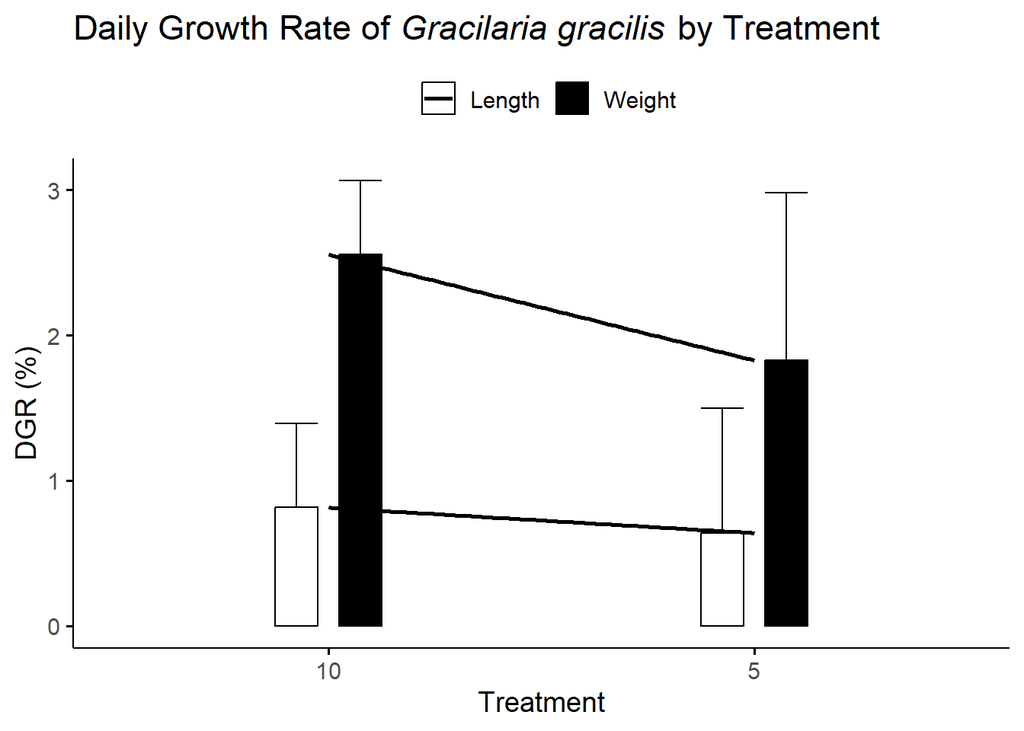

```r
library(ggplot2)
library(dplyr)

# Combine the two datasets, adding a column to distinguish length vs weight
gg_rgr_combined <- bind_rows(
  gg_avg_rgr_length %>% mutate(Type = "Length"),
  gg_avg_rgr_weight %>% mutate(Type = "Weight")
)


gg_rgr_combined_plot <- gg_rgr_combined %>%
  filter(Treatment %in% c(5, 10)) %>%
  group_by(Treatment, Type) %>%
  summarise(Mean_RGR_Per = mean(RGR_Per, na.rm = TRUE),
            RGR_Per_SE = mean(RGR_Per_SE, na.rm = TRUE),.groups = "drop") %>%
  ungroup()

# Plot
ggplot(gg_rgr_combined_plot, aes(x = Treatment, y = Mean_RGR_Per, fill = Type)) +
  geom_col(position = position_dodge(width = 0.3), color = "black", width = 0.2) +
    geom_errorbar(aes(ymin = Mean_RGR_Per, ymax = Mean_RGR_Per + RGR_Per_SE),
                width = 0.2, position = position_dodge(width = 0.3)) +
  scale_fill_grey(start = 1, end = 0) +
  geom_smooth(aes(group = Type), color = "black",method = "lm", se = FALSE, linetype = "solid") +
  labs(
    title = expression("Daily Growth Rate of " * italic("Gracilaria gracilis") * " by Treatment"),
    x = "Treatment",
    y = "DGR (%)",
    fill = "",
    color = ""
  ) +
  theme_classic(base_size = 14) +
  theme(
    axis.line = element_line(color = "black", size = 0.5),
    axis.ticks = element_line(color = "black"),
    legend.position = "top"
  )
```

Combine Weight and Length DGRs in bar graph for *Gracilariopsis longissima*

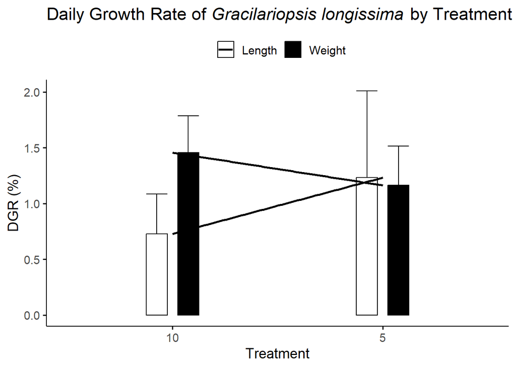

```r
# Combine the two datasets, adding a column to distinguish length vs weight
gl_rgr_combined <- bind_rows(
  gl_avg_rgr_length %>% mutate(Type = "Length"),
  gl_avg_rgr_weight %>% mutate(Type = "Weight")
)




gl_rgr_combined_plot <- gl_rgr_combined %>%
  filter(Treatment %in% c(5, 10)) %>%
  group_by(Treatment, Type) %>%
  summarise(Mean_RGR_Per = mean(RGR_Per, na.rm = TRUE),
            RGR_Per_SE = mean(RGR_Per_SE, na.rm = TRUE),.groups = "drop") %>%
  ungroup()

# Plot
ggplot(gl_rgr_combined_plot, aes(x = Treatment, y = Mean_RGR_Per, fill = Type)) +
  geom_col(position = position_dodge(width = 0.3), color = "black", width = 0.2) +
    geom_errorbar(aes(ymin = Mean_RGR_Per, ymax = Mean_RGR_Per + RGR_Per_SE),
                width = 0.2, position = position_dodge(width = 0.3)) +
  scale_fill_grey(start = 1, end = 0) +
  geom_smooth(aes(group = Type),color = "black", method = "lm", se = FALSE, linetype = "solid") +
  labs(
    title = expression("Daily Growth Rate of " * italic("Gracilariopsis longissima") * " by Treatment"),
    x = "Treatment",
    y = "DGR (%)",
    fill = "",
    color = ""
  ) +
  theme_classic(base_size = 14) +
  theme(
    axis.line = element_line(color = "black", size = 0.5),
    axis.ticks = element_line(color = "black"),
    legend.position = "top"
  )
```

Bar graph of Final lengths and weights of *Gracilariopsis longissima*

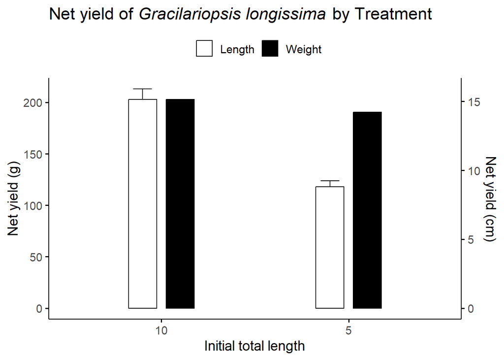

```r
gl_combined <- bind_rows(
  gl_avg_length %>% mutate(Type = "Length"),
  gl_avg_weight %>% mutate(Type = "Weight"))

gl_combined_plot <- gl_combined %>%
  filter(Treatment %in% c(5, 10), Week == "3") %>%
  group_by(Treatment, Type) %>%
  summarise(Net_Yield = mean(Average, na.rm = TRUE),
   SE = mean(SE, na.rm = TRUE), .groups = "drop") %>%
  ungroup()


# plot

# Rescale length to match weight scale
# Find max values
max_weight <- max(gl_combined_plot$Net_Yield[gl_combined_plot$Type == "Weight"], na.rm = TRUE)
max_length <- max(gl_combined_plot$Net_Yield[gl_combined_plot$Type == "Length"], na.rm = TRUE)

scale_factor <- max_weight / max_length

gl_combined_plot <- gl_combined_plot %>%
  mutate(Net_Yield_scaled = ifelse(Type == "Length", Net_Yield * scale_factor, Net_Yield),
         SE_scaled = ifelse(Type == "Length", SE * scale_factor, SE))

ggplot(gl_combined_plot, aes(x = factor(Treatment), fill = Type)) +
  geom_col(aes(y = Net_Yield_scaled),
           position = position_dodge(width = 0.4),
           color = "black", width = 0.3) +
  geom_errorbar(aes(ymin = Net_Yield_scaled, ymax = Net_Yield_scaled + SE_scaled),
                width = 0.2, position = position_dodge(width = 0.4)) +
  scale_fill_grey(start = 1, end = 0) +
  scale_y_continuous(
    name = "Net yield (g)",
    sec.axis = sec_axis(~ . / scale_factor, name = "Net yield (cm)")
  ) +
  labs(
    title = expression("Net yield of " * italic("Gracilariopsis longissima") * " by Treatment"),
    x = "Initial total length",
    fill = ""
  ) +
  theme_classic(base_size = 14) +
  theme(
    axis.line = element_line(color = "black", size = 0.5),
    axis.ticks = element_line(color = "black"),
    legend.position = "top"
  )
```

Bar graph of Final lengths and weights of *Gracilaria gracilis*

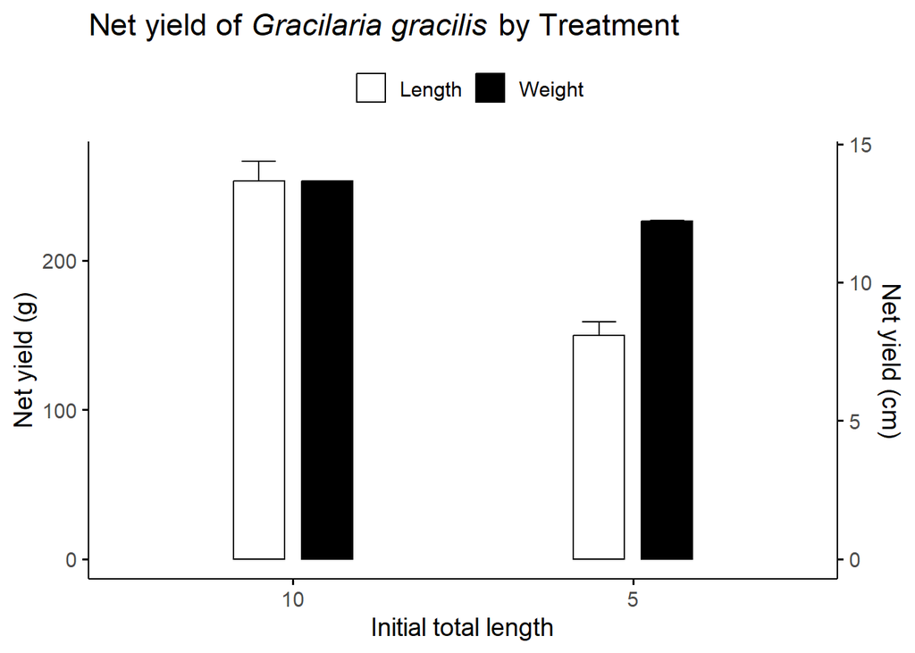

```r
gg_combined <- bind_rows(
  gg_avg_length %>% mutate(Type = "Length"),
  gg_avg_weight %>% mutate(Type = "Weight"))

gg_combined_plot <- gg_combined %>%
  filter(Treatment %in% c(5, 10), Week == "3") %>%
  group_by(Treatment, Type) %>%
  summarise(Net_Yield = mean(Average, na.rm = TRUE),
   SE = mean(SE, na.rm = TRUE))
# plot

# Rescale length to match weight scale
# Find max values
max_weight <- max(gg_combined_plot$Net_Yield[gg_combined_plot$Type == "Weight"], na.rm = TRUE)
max_length <- max(gg_combined_plot$Net_Yield[gg_combined_plot$Type == "Length"], na.rm = TRUE)

scale_factor <- max_weight / max_length

gg_combined_plot <- gg_combined_plot %>%
  mutate(Net_Yield_scaled = ifelse(Type == "Length", Net_Yield * scale_factor, Net_Yield),
         SE_scaled = ifelse(Type == "Length", SE * scale_factor, SE))

ggplot(gg_combined_plot, aes(x = factor(Treatment), fill = Type)) +
  geom_col(aes(y = Net_Yield_scaled),
           position = position_dodge(width = 0.4),
           color = "black", width = 0.3) +
  geom_errorbar(aes(ymin = Net_Yield_scaled, ymax = Net_Yield_scaled + SE_scaled),
                width = 0.2, position = position_dodge(width = 0.4)) +
  scale_fill_grey(start = 1, end = 0) +
  scale_y_continuous(
    name = "Net yield (g)",
    sec.axis = sec_axis(~ . / scale_factor, name = "Net yield (cm)")
  ) +
  labs(
    title = expression("Net yield of " * italic("Gracilaria gracilis") * " by Treatment"),
    x = "Initial total length",
    fill = ""
  ) +
  theme_classic(base_size = 14) +
  theme(
    axis.line = element_line(color = "black", size = 0.5),
    axis.ticks = element_line(color = "black"),
    legend.position = "top"
  )
```